# Librerías

```python
# Librerías básicas
import numpy as np
import matplotlib.pyplot as plt
import pandas as pd
import os, sys
import seaborn as sns
import warnings
warnings.filterwarnings('ignore')

from itertools import groupby
from IPython.display import display
pd.options.display.max_columns = None
```

```python
import re
import unidecode  # La biblioteca unidecode se usa para quitar tildes y reemplazar caracteres especiales
from unicodedata import normalize
```

```python
from scipy.stats import fisher_exact, chi2_contingency
import statsmodels.api as sm
```

```python
# Librerías ML
import sklearn
from sklearn.model_selection import train_test_split
from sklearn.preprocessing import LabelEncoder, StandardScaler
from sklearn.linear_model import LogisticRegression
# from sklearn.feature_selection import RFE
from sklearn.metrics import confusion_matrix, accuracy_score, recall_score, precision_score, f1_score, roc_auc_score, roc_curve, auc, r2_score


# from sklearn.tree import DecisionTreeRegressor

# import tensorflow as tf
# from tensorflow import keras
# from tensorflow import optimizers
# from tensorflow.keras import layers
# from tensorflow.keras.models import Sequential
# from tensorflow.keras.layers import Dense

# from sklearn.neural_network import MLPClassifier
# from sklearn.model_selection import RandomizedSearchCV
# from sklearn.model_selection import GridSearchCV
# from sklearn.model_selection import KFold
# import multiprocessing
```

```python
# Librerías KNN
from sklearn.neighbors import KNeighborsClassifier
```

```python
# Librerías DecisionTree
from sklearn.tree import DecisionTreeClassifier
from sklearn import tree
```

```python
# Librería para uso de R en el notebook
import rpy2.robjects as ro
from rpy2.robjects import pandas2ri
from rpy2.robjects.vectors import ListVector
```

# Definiciones

```python
def describe_columnas(df, lista_columnas):

    for i in lista_columnas:

        print('Características de la columna', i)
        print('- Tipo de datos:', df[i].dtype)
        print('- Número de filas:', df[i].shape[0] )
        print('- Recuento de los valores únicos son:')

        diccionario = {}
        suma_valores = {}

        for j in df[i].tolist():
            diccionario[j] = diccionario.get(j,0) + 1

        for clave, valor in diccionario.items():
            if clave in suma_valores:
                suma_valores[clave] += valor
            else:
                suma_valores[clave] = valor

        diccionario_ordenado = dict(sorted(suma_valores.items(), key=lambda x: x[1], reverse=True))

        for clave, valor in diccionario_ordenado.items():
            print(clave, '=', valor)
```

```python
# Definiciones comparativas

def relaciones_vs_target(X, Y, return_type='axes'):
    fig_tot = (len(X.columns))
    fig_por_fila = 4.
    tamanio_fig = 4.
    num_filas = int( np.ceil(fig_tot/fig_por_fila) )
    plt.figure( figsize=( fig_por_fila*tamanio_fig+5, num_filas*tamanio_fig+5 ) )
    c = 0
    for i, col in enumerate(X.columns):
        plt.subplot(num_filas, fig_por_fila, i+1)
        sns.scatterplot(x=X[col], y=Y)
        plt.title( '%s vs %s' % (col, 'target') )
        plt.ylabel('Target')
        plt.xlabel(col)
    plt.show()

def represento_doble_hist(x_1, x_0, n_bins=11, title='', label_1='Clase 1',
                          label_0='Clase 0', normed=0):
    bins = n_bins
    plt.hist(x_1, bins, normed = normed, alpha=0.5, label=label_1, color='red')
    plt.hist(x_0, bins, normed = normed, alpha=0.5, label=label_0, color='green')
    plt.title(title)
    plt.legend(loc='best')

def hist_pos_neg_feat(x, y, normed=0, nbins=11, targets=(0,1)):
    fig_tot = len(x.columns)
    fig_tot_fila = 4.; fig_tamanio = 4.
    num_filas = int( np.ceil(fig_tot/fig_tot_fila) )
    plt.figure( figsize=( fig_tot_fila*fig_tamanio+2, num_filas*fig_tamanio+2 ) )
    target_neg, target_pos = targets
    for i, feat in enumerate(x.columns):
        plt.subplot(num_filas, fig_tot_fila, i+1);
        plt.title('%s' % feat)
        idx_pos = y == target_pos
        idx_neg= y == target_neg
        represento_doble_hist(x[feat][idx_pos].values, x[feat][idx_neg].values, nbins,
                   normed = normed, title=('%s' % feat))
```

```python
# Definicion normalización de texto
def elimina_diacriticos(s):
    s = re.sub(
        r'([^n\u0300-\u036f]|n(?!\u0303(?![\u0300-\u036f])))[\u0300-\u036f]+', r'\1',
        normalize('NFD', s), 0, re.I
    )

    s = normalize('NFC', s)

    return s
```

# Descripción de los datos

```python
# XY = pd.read_parquet('C:/Users/cgonzalez-novo.ISDEFE/OneDrive - ISDEFE/Carlos G-NM/TFM/Dataset_model.parquet')
XY = pd.read_parquet('C:/Users/Usuario/OneDrive - ISDEFE/Carlos G-NM/TFM/Dataset_model.parquet')
```

```python
print(u'- El número de filas en el dataset es: {}'.format(XY.shape[0]))
print(u'- El número de columnas en el dataset es: {}'.format(XY.shape[1]))
print(u'- Las variables no numéricas son:'.format(XY.select_dtypes(exclude = ['number']).columns.tolist()))
print(u'- Los nombres de las variables independientes son: {}'.format(list(XY.columns)))

XY[:5]
```

```
- El número de filas en el dataset es: 42660
- El número de columnas en el dataset es: 44
- Las variables no numéricas son:
- Los nombres de las variables independientes son: ['ref_cat', 'num_m2_const', 'cod_prov_INE', 'cod_mun_INE', 'num_año', 'longitud', 'latitud', 'altitud', 'renta_neta_por_hogar', 'No tenía ref_cat válida', 'Clase-Rural', 'Clase-Urbano', 'Reforma media', 'Reforma mínima', 'Reforma total', 'Rehabilita…
```

|  | ref_cat | num_m2_const | cod_prov_INE | cod_mun_INE | num_año | longitud | latitud | altitud | renta_neta_por_hogar | No tenía ref_cat válida | Clase-Rural | Clase-Urbano | Reforma media | Reforma mínima | Reforma total | Rehabilitación integral | Sin reformar | Badajoz | Cáceres | ZC-C3 | ZC-C4 | ZC-D3 | ZC-E1 | Agrario | Almacén - Estacionamiento | Comercial | Cultural | Deportivo | Edificio singular | … |
| --- | --- | --- | --- | --- | --- | --- | --- | --- | --- | --- | --- | --- | --- | --- | --- | --- | --- | --- | --- | --- | --- | --- | --- | --- | --- | --- | --- | --- | --- | --- |
| 0 | 3195804TJ7239N0001ER | 138 | 6 | 1 | 2018 | -5.624040 | 39.083200 | 316 | 22.139 | 0.0 | 0 | 1 | 0 | 0 | 0 | 0 | 1 | 1 | 0 | 0 | 1 | 0 | 0 | 0 | 0 | 0 | 0 | 0 | 0 | … |
| 1 | 3195804TJ7239N0001ER | 123 | 6 | 1 | 2018 | -5.624040 | 39.083200 | 316 | 22.139 | 0.0 | 0 | 1 | 0 | 0 | 0 | 0 | 1 | 1 | 0 | 0 | 1 | 0 | 0 | 0 | 0 | 0 | 0 | 0 | 0 | … |
| 2 | 7585408TJ7278N0001IE | 108 | 6 | 1 | 1950 | -5.572806 | 39.076037 | 316 | 22.139 | 0.0 | 0 | 1 | 0 | 0 | 0 | 0 | 1 | 1 | 0 | 0 | 1 | 0 | 0 | 0 | 0 | 0 | 0 | 0 | 0 | … |
| 3 | 7584705TJ7278S0001AA | 113 | 6 | 1 | 1996 | -5.571800 | 39.074665 | 316 | 22.139 | 0.0 | 0 | 1 | 1 | 0 | 0 | 0 | 0 | 1 | 0 | 0 | 1 | 0 | 0 | 0 | 0 | 0 | 0 | 0 | 0 | … |
| 4 | 7584705TJ7278S0001AA | 21 | 6 | 1 | 2011 | -5.571800 | 39.074665 | 316 | 22.139 | 0.0 | 0 | 1 | 1 | 0 | 0 | 0 | 0 | 1 | 0 | 0 | 1 | 0 | 0 | 0 | 0 | 0 | 0 | 0 | 0 | … |

```python
XY.dtypes
```

```
ref_cat                                                     object
num_m2_const                                                 int64
cod_prov_INE                                                 int32
cod_mun_INE                                                  int32
num_año                                                      int64
longitud                                                   float64
latitud                                                    float64
altitud                                                      int64
renta_neta_por_hogar                                       float64
No tenía ref_cat válida                                    float64
Clase-Rural                                                  int32
Clase-Urbano                                                 int32
Reforma media                                                int32
Reforma mínima                                               int32
Reforma total                                                int32
Rehabilitación integral                                      int32
Sin reformar                                                 int32
Badajoz                                                      uint8
Cáceres                                                      uint8
ZC-C3                                                        int32
ZC-C4                                                        int32
ZC-D3                                                        int32
ZC-E1                                                        int32
Agrario                                                      int32
Almacén - Estacionamiento                                    int32
Comercial                                                    int32
Cultural                                                     int32
Deportivo                                                    int32
Edificio singular                                            int32
Espectáculos                                                 int32
Industrial                                                   int32
Obras de urbanización y jardinería, suelos sin edificar      int32
Ocio y Hostelería                                            int32
Oficinas                                                     int32
Religioso                                                    int32
Residencial                                                  int32
Sanidad y Beneficencia                                       int32
A                                                            int32
B                                                            int32
C                                                            int32
D                                                            int32
E                                                            int32
F                                                            int32
G                                                            int32
dtype: object
```

```python
print('Nulos totales:',XY.isnull().sum())
XY[:3]
```

```
Nulos totales: ref_cat                                                    0
num_m2_const                                               0
cod_prov_INE                                               0
cod_mun_INE                                                0
num_año                                                    0
longitud                                                   0
latitud                                                    0
altitud                                                    0
renta_neta_por_hogar                                       0
No tenía ref_cat válida                                    0
Clase-Rural                                                0
Clase-Urbano                                               0
Reforma media                                              0
Reforma mínima                                             0
Reforma total                                              0
Rehabilitación integral                                    0
Sin reformar                                               0
Badajoz                                                    0
Cáceres                                                    0
ZC-C3                                                      0
ZC-C4                                                      0
ZC-D3                                                      0
ZC-E1                                                      0
Agrario                                                    0
Almacén - Estacionamiento                                  0
Comercial                                                  0
Cultural                                                   0
Deportivo                                                  0
Edificio singular                                          0
Espectáculos                                               0
Industrial                                                 0
Obras de urbanización y jardinería, suelos sin edificar    0
Ocio y Hostelería                                          0
Oficinas                                                   0
Religioso                                                  0
Residencial                                                0
Sanidad y Beneficencia                                     0
A                                                          0
B                                                          0
C                                                          0
D                                                          0
E                                                          0
F                                                          0
G                                                          0
dtype: int64
```

|  | ref_cat | num_m2_const | cod_prov_INE | cod_mun_INE | num_año | longitud | latitud | altitud | renta_neta_por_hogar | No tenía ref_cat válida | Clase-Rural | Clase-Urbano | Reforma media | Reforma mínima | Reforma total | Rehabilitación integral | Sin reformar | Badajoz | Cáceres | ZC-C3 | ZC-C4 | ZC-D3 | ZC-E1 | Agrario | Almacén - Estacionamiento | Comercial | Cultural | Deportivo | Edificio singular | … |
| --- | --- | --- | --- | --- | --- | --- | --- | --- | --- | --- | --- | --- | --- | --- | --- | --- | --- | --- | --- | --- | --- | --- | --- | --- | --- | --- | --- | --- | --- | --- |
| 0 | 3195804TJ7239N0001ER | 138 | 6 | 1 | 2018 | -5.624040 | 39.083200 | 316 | 22.139 | 0.0 | 0 | 1 | 0 | 0 | 0 | 0 | 1 | 1 | 0 | 0 | 1 | 0 | 0 | 0 | 0 | 0 | 0 | 0 | 0 | … |
| 1 | 3195804TJ7239N0001ER | 123 | 6 | 1 | 2018 | -5.624040 | 39.083200 | 316 | 22.139 | 0.0 | 0 | 1 | 0 | 0 | 0 | 0 | 1 | 1 | 0 | 0 | 1 | 0 | 0 | 0 | 0 | 0 | 0 | 0 | 0 | … |
| 2 | 7585408TJ7278N0001IE | 108 | 6 | 1 | 1950 | -5.572806 | 39.076037 | 316 | 22.139 | 0.0 | 0 | 1 | 0 | 0 | 0 | 0 | 1 | 1 | 0 | 0 | 1 | 0 | 0 | 0 | 0 | 0 | 0 | 0 | 0 | … |

```python
XY.describe()
```

|  | num_m2_const | cod_prov_INE | cod_mun_INE | num_año | longitud | latitud | altitud | renta_neta_por_hogar | No tenía ref_cat válida | Clase-Rural | Clase-Urbano | Reforma media | Reforma mínima | Reforma total | Rehabilitación integral | Sin reformar | Badajoz | Cáceres | ZC-C3 | ZC-C4 | ZC-D3 | ZC-E1 | Agrario | Almacén - Estacionamiento | Comercial | Cultural | Deportivo | Edificio singular | Espectáculos | … |
| --- | --- | --- | --- | --- | --- | --- | --- | --- | --- | --- | --- | --- | --- | --- | --- | --- | --- | --- | --- | --- | --- | --- | --- | --- | --- | --- | --- | --- | --- | --- |
| count | 42660.000000 | 42660.000000 | 42660.000000 | 42660.000000 | 42660.000000 | 42660.000000 | 42660.000000 | 42660.000000 | 42660.0 | 42660.0 | 42660.0 | 42660.000000 | 42660.000000 | 42660.000000 | 42660.000000 | 42660.000000 | 42660.000000 | 42660.000000 | 42660.000000 | 42660.000000 | 42660.000000 | 42660.000000 | 42660.0 | 42660.000000 | 42660.000000 | 42660.000000 | 42660.000000 | 42660.000000 | 42660.0 | … |
| mean | 86.702414 | 7.537178 | 70.311814 | 1989.450023 | -6.435394 | 39.163415 | 327.885373 | 27.295406 | 0.0 | 0.0 | 1.0 | 0.067417 | 0.026067 | 0.021542 | 0.091913 | 0.793061 | 0.615706 | 0.384294 | 0.025316 | 0.899648 | 0.074355 | 0.000680 | 0.0 | 0.000750 | 0.000234 | 0.000774 | 0.000281 | 0.000070 | 0.0 | … |
| std | 43.551190 | 1.945735 | 85.514982 | 26.928634 | 0.445382 | 0.493922 | 138.240297 | 5.772527 | 0.0 | 0.0 | 0.0 | 0.250745 | 0.159335 | 0.145186 | 0.288906 | 0.405116 | 0.486434 | 0.486434 | 0.157086 | 0.300472 | 0.262351 | 0.026064 | 0.0 | 0.027378 | 0.015309 | 0.027802 | 0.016770 | 0.008386 | 0.0 | … |
| min | 1.000000 | 6.000000 | 1.000000 | 0.000000 | -7.501654 | 38.065023 | 181.000000 | 14.302000 | 0.0 | 0.0 | 1.0 | 0.000000 | 0.000000 | 0.000000 | 0.000000 | 0.000000 | 0.000000 | 0.000000 | 0.000000 | 0.000000 | 0.000000 | 0.000000 | 0.0 | 0.000000 | 0.000000 | 0.000000 | 0.000000 | 0.000000 | 0.0 | … |
| 25% | 61.000000 | 6.000000 | 15.000000 | 1977.000000 | -6.913293 | 38.872296 | 184.000000 | 23.361000 | 0.0 | 0.0 | 1.0 | 0.000000 | 0.000000 | 0.000000 | 0.000000 | 1.000000 | 0.000000 | 0.000000 | 0.000000 | 1.000000 | 0.000000 | 0.000000 | 0.0 | 0.000000 | 0.000000 | 0.000000 | 0.000000 | 0.000000 | 0.0 | … |
| 50% | 82.000000 | 6.000000 | 37.000000 | 1996.000000 | -6.381696 | 38.922885 | 293.000000 | 26.197000 | 0.0 | 0.0 | 1.0 | 0.000000 | 0.000000 | 0.000000 | 0.000000 | 1.000000 | 1.000000 | 0.000000 | 0.000000 | 1.000000 | 0.000000 | 0.000000 | 0.0 | 0.000000 | 0.000000 | 0.000000 | 0.000000 | 0.000000 | 0.0 | … |
| 75% | 105.000000 | 10.000000 | 97.000000 | 2006.000000 | -6.275400 | 39.472403 | 457.000000 | 30.499000 | 0.0 | 0.0 | 1.0 | 0.000000 | 0.000000 | 0.000000 | 0.000000 | 1.000000 | 1.000000 | 1.000000 | 0.000000 | 1.000000 | 0.000000 | 0.000000 | 0.0 | 0.000000 | 0.000000 | 0.000000 | 0.000000 | 0.000000 | 0.0 | … |
| max | 1245.000000 | 10.000000 | 905.000000 | 2022.000000 | -4.790068 | 40.466477 | 1176.000000 | 39.879000 | 0.0 | 0.0 | 1.0 | 1.000000 | 1.000000 | 1.000000 | 1.000000 | 1.000000 | 1.000000 | 1.000000 | 1.000000 | 1.000000 | 1.000000 | 1.000000 | 0.0 | 1.000000 | 1.000000 | 1.000000 | 1.000000 | 1.000000 | 0.0 | … |

# Análisis de variables

```python
# Se eliminan las variables que tienen todos los valores iguales
XY.drop(['cod_prov_INE','No tenía ref_cat válida', 'Clase-Rural', 'Clase-Urbano', 'Agrario', 'Espectáculos', 'Religioso', 'Sanidad y Beneficencia'], axis= 1, inplace= True)
```

```python
XY.describe()
```

|  | num_m2_const | cod_mun_INE | num_año | longitud | latitud | altitud | renta_neta_por_hogar | Reforma media | Reforma mínima | Reforma total | Rehabilitación integral | Sin reformar | Badajoz | Cáceres | ZC-C3 | ZC-C4 | ZC-D3 | ZC-E1 | Almacén - Estacionamiento | Comercial | Cultural | Deportivo | Edificio singular | Industrial | Obras de urbanización y jardinería, suelos sin edificar | Ocio y Hostelería | Oficinas | Residencial | A | … |
| --- | --- | --- | --- | --- | --- | --- | --- | --- | --- | --- | --- | --- | --- | --- | --- | --- | --- | --- | --- | --- | --- | --- | --- | --- | --- | --- | --- | --- | --- | --- |
| count | 42660.000000 | 42660.000000 | 42660.000000 | 42660.000000 | 42660.000000 | 42660.000000 | 42660.000000 | 42660.000000 | 42660.000000 | 42660.000000 | 42660.000000 | 42660.000000 | 42660.000000 | 42660.000000 | 42660.000000 | 42660.000000 | 42660.000000 | 42660.000000 | 42660.000000 | 42660.000000 | 42660.000000 | 42660.000000 | 42660.000000 | 42660.000000 | 42660.000000 | 42660.000000 | 42660.000000 | 42660.000000 | 42660.000000 | … |
| mean | 86.702414 | 70.311814 | 1989.450023 | -6.435394 | 39.163415 | 327.885373 | 27.295406 | 0.067417 | 0.026067 | 0.021542 | 0.091913 | 0.793061 | 0.615706 | 0.384294 | 0.025316 | 0.899648 | 0.074355 | 0.000680 | 0.000750 | 0.000234 | 0.000774 | 0.000281 | 0.000070 | 0.000398 | 0.000164 | 0.000047 | 0.000281 | 0.997000 | 0.020183 | … |
| std | 43.551190 | 85.514982 | 26.928634 | 0.445382 | 0.493922 | 138.240297 | 5.772527 | 0.250745 | 0.159335 | 0.145186 | 0.288906 | 0.405116 | 0.486434 | 0.486434 | 0.157086 | 0.300472 | 0.262351 | 0.026064 | 0.027378 | 0.015309 | 0.027802 | 0.016770 | 0.008386 | 0.019959 | 0.012809 | 0.006847 | 0.016770 | 0.054695 | 0.140627 | … |
| min | 1.000000 | 1.000000 | 0.000000 | -7.501654 | 38.065023 | 181.000000 | 14.302000 | 0.000000 | 0.000000 | 0.000000 | 0.000000 | 0.000000 | 0.000000 | 0.000000 | 0.000000 | 0.000000 | 0.000000 | 0.000000 | 0.000000 | 0.000000 | 0.000000 | 0.000000 | 0.000000 | 0.000000 | 0.000000 | 0.000000 | 0.000000 | 0.000000 | 0.000000 | … |
| 25% | 61.000000 | 15.000000 | 1977.000000 | -6.913293 | 38.872296 | 184.000000 | 23.361000 | 0.000000 | 0.000000 | 0.000000 | 0.000000 | 1.000000 | 0.000000 | 0.000000 | 0.000000 | 1.000000 | 0.000000 | 0.000000 | 0.000000 | 0.000000 | 0.000000 | 0.000000 | 0.000000 | 0.000000 | 0.000000 | 0.000000 | 0.000000 | 1.000000 | 0.000000 | … |
| 50% | 82.000000 | 37.000000 | 1996.000000 | -6.381696 | 38.922885 | 293.000000 | 26.197000 | 0.000000 | 0.000000 | 0.000000 | 0.000000 | 1.000000 | 1.000000 | 0.000000 | 0.000000 | 1.000000 | 0.000000 | 0.000000 | 0.000000 | 0.000000 | 0.000000 | 0.000000 | 0.000000 | 0.000000 | 0.000000 | 0.000000 | 0.000000 | 1.000000 | 0.000000 | … |
| 75% | 105.000000 | 97.000000 | 2006.000000 | -6.275400 | 39.472403 | 457.000000 | 30.499000 | 0.000000 | 0.000000 | 0.000000 | 0.000000 | 1.000000 | 1.000000 | 1.000000 | 0.000000 | 1.000000 | 0.000000 | 0.000000 | 0.000000 | 0.000000 | 0.000000 | 0.000000 | 0.000000 | 0.000000 | 0.000000 | 0.000000 | 0.000000 | 1.000000 | 0.000000 | … |
| max | 1245.000000 | 905.000000 | 2022.000000 | -4.790068 | 40.466477 | 1176.000000 | 39.879000 | 1.000000 | 1.000000 | 1.000000 | 1.000000 | 1.000000 | 1.000000 | 1.000000 | 1.000000 | 1.000000 | 1.000000 | 1.000000 | 1.000000 | 1.000000 | 1.000000 | 1.000000 | 1.000000 | 1.000000 | 1.000000 | 1.000000 | 1.000000 | 1.000000 | 1.000000 | … |

Se analizan a continuacion algunas variables en función del tipo de calificación energética

```python
# Analizamos los datos de las variables num_año y num_m2_const para cada posible certificación
for cert in ['A', 'B', 'C', 'D', 'E', 'F', 'G']:
    print('Descripción de años de', cert, ': \n',XY[(XY[cert] == 1)][['num_año','num_m2_const','renta_neta_por_hogar']].describe())
```

```
Descripción de años de A :
            num_año  num_m2_const  renta_neta_por_hogar
count   861.000000    861.000000            861.000000
mean   1996.154472     98.420441             25.370786
std     100.736950     47.796368              5.084158
min       0.000000      2.000000             16.105000
25%    1984.000000     70.000000             22.134000
50%    2018.000000     93.000000             23.898000
75%    2020.000000    124.000000             28.185000
max    2022.000000    404.000000             39.879000
Descripción de años de B :
            num_año  num_m2_const  renta_neta_por_hogar
count  1280.000000   1280.000000           1280.000000
mean   2008.877344     86.830469             24.712839
std      22.988112     53.988490              4.248504
min    1890.000000      2.000000             15.101000
25%    2010.000000     56.000000             21.593000
50%    2018.000000     76.000000             23.951000
75%    2019.000000    112.000000             27.643000
max    2022.000000    766.000000             39.879000
Descripción de años de C :
            num_año  num_m2_const  renta_neta_por_hogar
count  1414.000000    1414.00000           1414.000000
mean   2000.905233      91.65983             26.224004
std      18.706155      74.09902              5.174007
min    1900.000000       3.00000             16.258000
25%    1998.000000      56.25000             23.109000
50%    2007.000000      76.00000             25.450000
75%    2010.000000     110.00000             28.459000
max    2022.000000     995.00000             39.879000
Descripción de años de D :
            num_año  num_m2_const  renta_neta_por_hogar
count  6145.000000   6145.000000           6145.000000
mean   1996.574125     86.275020             26.985718
std      19.868540     47.630272              5.349492
min    1850.000000      1.000000             16.105000
25%    1992.000000     61.000000             23.581000
50%    2004.000000     76.000000             26.060000
75%    2008.000000    104.000000             29.451000
max    2022.000000   1017.000000             39.879000
```

[output cut: 15 more lines]

```
min    1189.000000      3.000000             15.499000
25%    1969.000000     58.000000             22.652000
50%    1983.000000     79.000000             26.060000
75%    2000.000000    104.000000             29.658000
max    2022.000000   1106.000000             39.879000
Descripción de años de G :
            num_año  num_m2_const  renta_neta_por_hogar
count  3358.000000   3358.000000           3358.000000
mean   1979.138475     83.876415             27.627837
std      27.102134     38.693720              5.856319
min    1060.000000      2.000000             14.664000
25%    1968.000000     60.000000             23.357000
50%    1980.000000     81.000000             27.793000
75%    1997.000000    101.000000             31.975000
max    2022.000000    596.000000             39.879000
```

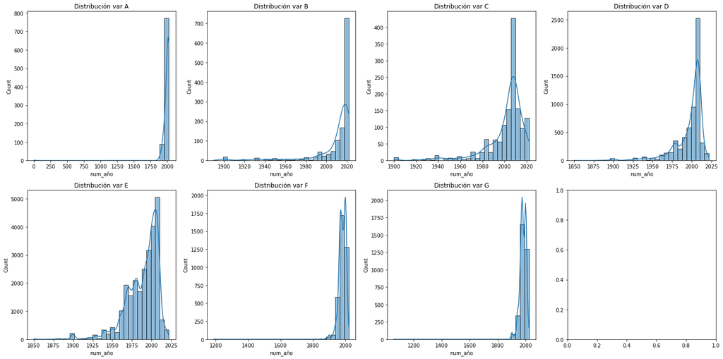

```python
fig, axes = plt.subplots(2, 4, figsize=(20, 10))
axes = axes.flatten()

for i, column in enumerate(['A', 'B', 'C', 'D', 'E', 'F', 'G']):
    sns.histplot(data=XY[XY[column] == 1], x='num_año', bins=30, kde=True, ax=axes[i])
    axes[i].set_title('Distribución var {}'.format(column))

plt.tight_layout()
plt.show()
```

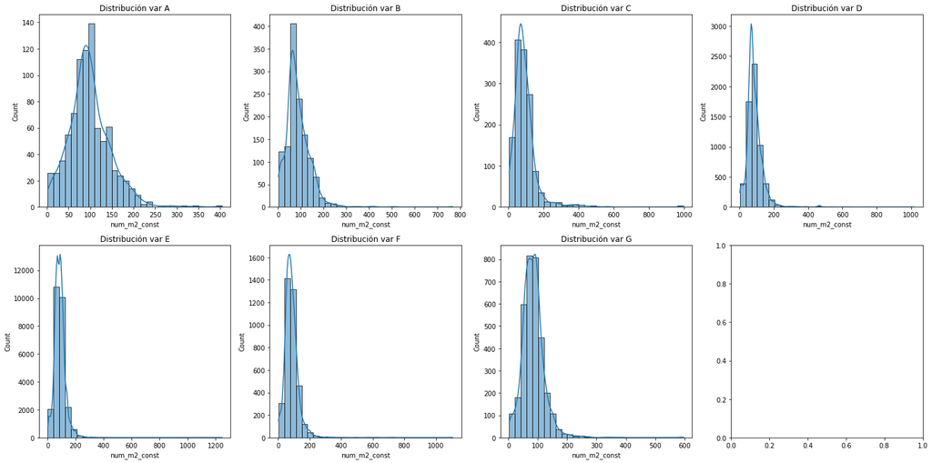

```python
fig, axes = plt.subplots(2, 4, figsize=(20, 10))
axes = axes.flatten()

for i, column in enumerate(['A', 'B', 'C', 'D', 'E', 'F', 'G']):
    sns.histplot(data=XY[XY[column] == 1], x='num_m2_const', bins=30, kde=True, ax=axes[i])
    axes[i].set_title('Distribución var {}'.format(column))

plt.tight_layout()
plt.show()
```

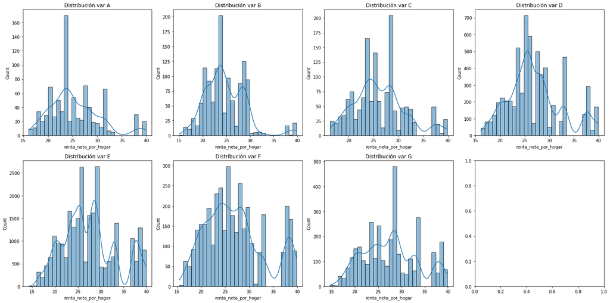

```python
fig, axes = plt.subplots(2, 4, figsize=(20, 10))
axes = axes.flatten()

for i, column in enumerate(['A', 'B', 'C', 'D', 'E', 'F', 'G']):
    sns.histplot(data=XY[XY[column] == 1], x='renta_neta_por_hogar', bins=30, kde=True, ax=axes[i])
    axes[i].set_title('Distribución var {}'.format(column))

plt.tight_layout()
plt.show()
```

Debido a estas circunstancias es muy probable que el modelo no sea capaz de predecir con una confianza suficinete el tipo de calificación energética. Por ello, se opta por agrupar las calificaciones de la siguiente manera:

- Es A o B.
- Es C o D
- Es E.
- Es F o G.

Esta agrupación está basada en similitudes en la distribución de los años, m2 y renta, así como en el número de registros de cada categoría.

Por último, se ha observado que la mayoría de los registros tipo A se encuentran en suelos sin edificar, es decir no aparecen en este database, es por ello que el número de registros con calificaciones elevadas es más escueto.

```python
XY['A-B'] = XY['A'] + XY['B']
XY['C-D'] = XY['C'] + XY['D']
XY['F-G'] = XY['F'] + XY['G']
```

```python
# Analizamos los datos de las variables num_año y num_m2_const para cada posible certificación
for cert in ['A-B', 'C-D', 'E', 'F-G']:
    print('Descripción de años de', cert, ': \n',XY[(XY[cert] == 1)][['num_año','num_m2_const','renta_neta_por_hogar']].describe())
```

```
Descripción de años de A-B :
            num_año  num_m2_const  renta_neta_por_hogar
count  2141.000000   2141.000000           2141.000000
mean   2003.760859     91.491359             24.977431
std      66.580138     51.888554              4.612983
min       0.000000      2.000000             15.101000
25%    2005.000000     59.000000             21.847000
50%    2018.000000     86.000000             23.951000
75%    2020.000000    116.000000             27.643000
max    2022.000000    766.000000             39.879000
Descripción de años de C-D :
            num_año  num_m2_const  renta_neta_por_hogar
count  7559.000000   7559.000000            7559.00000
mean   1997.384310     87.282312              26.84323
std      19.727566     53.620176               5.32506
min    1850.000000      1.000000              16.10500
25%    1993.000000     61.000000              23.57700
50%    2005.000000     76.000000              26.06000
75%    2009.000000    106.000000              29.45100
max    2022.000000   1017.000000              39.87900
Descripción de años de E :
             num_año  num_m2_const  renta_neta_por_hogar
count  25910.000000  25910.000000          25910.000000
mean    1988.378695     86.775762             27.607664
std       21.095941     39.425041              5.867441
min     1850.000000      1.000000             14.302000
25%     1977.000000     63.000000             23.536000
50%     1994.000000     84.000000             27.452000
75%     2004.000000    105.000000             30.902000
max     2022.000000   1245.000000             39.879000
Descripción de años de F-G :
            num_año  num_m2_const  renta_neta_por_hogar
count  7050.000000   7050.000000           7050.000000
mean   1980.534184     84.356738             27.336567
std      27.860255     43.039922              6.003713
min    1060.000000      2.000000             14.664000
25%    1969.000000     59.000000             23.033000
50%    1981.000000     80.000000             26.810000
75%    1998.000000    102.000000             30.902000
max    2022.000000   1106.000000             39.879000
```